# Hi-C contig processing

## 4.3 Connect plasmid clusters to resistance genes

- We’ve now clustered plasmid contigs, but which ones are also connected to resistance genes?
- Return to HiC links df with MAGs, plasmids, and resistance genes again
- This time keep only links between plasmid contigs and resistance genes

```r
links_resistance <- subset(WW_links_filt5, contig1_assignment != "MAG" & contig2_assignment != "MAG")
links_resistance <- subset(links_resistance, (contig1_assignment == "PLASMID" & contig2_assignment == "AMR") | (contig1_assignment == "AMR" & contig2_assignment == "PLASMID"))

# manipulate dataframe so all plasmids in left column and all resistance contigs in right column

plasmid_contig1<-subset(links_resistance, contig1_assignment == "PLASMID")
plasmid_contig2<-subset(links_resistance, contig2_assignment == "PLASMID")

plasmid_contig2<-plasmid_contig2[,c(2,1,3,5,4)]
names(plasmid_contig2)<-names(plasmid_contig1)

links_resistance2<-rbind(plasmid_contig1, plasmid_contig2)


links_resistance2<-subset(links_resistance2, V3>4) # only considered an AMR plasmid if found connected to an AMR gene at least 5 times

head(links_resistance2)
```

| V1 | V2 | V3 | contig1_assignment | contig2_assignment |
| --- | --- | --- | --- | --- |
| k141_1739103 | k141_1474880 | 7 | PLASMID | AMR |
| k141_1772484 | k141_2087656 | 6 | PLASMID | AMR |
| k141_2194155 | k141_2245618 | 5 | PLASMID | AMR |
| k141_2481168 | k141_1333187 | 7 | PLASMID | AMR |
| k141_2621312 | k141_1809171 | 8 | PLASMID | AMR |
| k141_2768091 | k141_1665904 | 5 | PLASMID | AMR |

```r
## what type of resistance is the AMR gene?

links_resistance2$Resistance<- vlookup(links_resistance2$V2, amr_genes, lookup_column = "contig", result_column = "Element.subtype")


links_resistance2$AMR_gene<- vlookup(links_resistance2$V2, amr_genes, lookup_column = "contig", result_column = "Gene.symbol")

head(links_resistance2)
```

| V1 | V2 | V3 | contig1_assignment | contig2_assignment | Resistance | AMR_gene |
| --- | --- | --- | --- | --- | --- | --- |
| k141_1739103 | k141_1474880 | 7 | PLASMID | AMR | AMR | tet(A) |
| k141_1772484 | k141_2087656 | 6 | PLASMID | AMR | AMR | blaAER |
| k141_2194155 | k141_2245618 | 5 | PLASMID | AMR | AMR | aph(6)-Id |
| k141_2481168 | k141_1333187 | 7 | PLASMID | AMR | AMR | tet(W) |
| k141_2621312 | k141_1809171 | 8 | PLASMID | AMR | AMR | icr-Mo |
| k141_2768091 | k141_1665904 | 5 | PLASMID | AMR | METAL | ncrA |

```r
# make column indicating whether resistance gene in an AMR gene (rather than metal resistance, etc)

links_resistance2$Resistance2<- links_resistance2$V2 %in% subset(amr_genes, Element.type == "AMR")$contig

head(links_resistance2)
```

| V1 | V2 | V3 | contig1_assignment | contig2_assignment | Resistance | AMR_gene | Resistance2 |
| --- | --- | --- | --- | --- | --- | --- | --- |
| k141_1739103 | k141_1474880 | 7 | PLASMID | AMR | AMR | tet(A) | TRUE |
| k141_1772484 | k141_2087656 | 6 | PLASMID | AMR | AMR | blaAER | TRUE |
| k141_2194155 | k141_2245618 | 5 | PLASMID | AMR | AMR | aph(6)-Id | TRUE |
| k141_2481168 | k141_1333187 | 7 | PLASMID | AMR | AMR | tet(W) | TRUE |
| k141_2621312 | k141_1809171 | 8 | PLASMID | AMR | AMR | icr-Mo | TRUE |
| k141_2768091 | k141_1665904 | 5 | PLASMID | AMR | METAL | ncrA | FALSE |

```r
# only keep links that involve AMR resistance
links_resistance3<-subset(links_resistance2, Resistance2 == TRUE)

head(links_resistance3)
```

| V1 | V2 | V3 | contig1_assignment | contig2_assignment | Resistance | AMR_gene | Resistance2 |
| --- | --- | --- | --- | --- | --- | --- | --- |
| k141_1739103 | k141_1474880 | 7 | PLASMID | AMR | AMR | tet(A) | TRUE |
| k141_1772484 | k141_2087656 | 6 | PLASMID | AMR | AMR | blaAER | TRUE |
| k141_2194155 | k141_2245618 | 5 | PLASMID | AMR | AMR | aph(6)-Id | TRUE |
| k141_2481168 | k141_1333187 | 7 | PLASMID | AMR | AMR | tet(W) | TRUE |
| k141_2621312 | k141_1809171 | 8 | PLASMID | AMR | AMR | icr-Mo | TRUE |
| k141_1905885 | k141_307872 | 21 | PLASMID | AMR | AMR | aadA27 | TRUE |

```r
############## now lets put this info back into plasmid link table

# make datafrmae with cluster and resistance into for each (clustered) plasmid contig

cluster_df<- n[,c(3,5)]
cluster_df<-unique(cluster_df)




# add column with whether contig is connected to an AMR gene
cluster_df$Resistance<-cluster_df$name %in% links_resistance3$V1
cluster_df<-cluster_df%>% arrange(ClusterMembership)
cluster_df$Gene <- vlookup(cluster_df$name, links_resistance3, lookup_column = "V1", result_column = "AMR_gene")

head(cluster_df)
```

|  | name | ClusterMembership | Resistance | Gene |
| --- | --- | --- | --- | --- |
| 443 | k141_526738 | 1 | FALSE | NA |
| 455 | k141_1145966 | 1 | FALSE | NA |
| 458 | k141_1856898 | 1 | FALSE | NA |
| 464 | k141_971894 | 1 | FALSE | NA |
| 474 | k141_973004 | 1 | FALSE | NA |
| 480 | k141_190742 | 1 | FALSE | NA |

```r
table(cluster_df$Gene)
```

```
##
##     aadA27       aadS  aph(6)-Id     blaAER     blaMCA      cmlA5     mph(A)
##          4          1          2          1          1          1          1
##     msr(E) qacEdelta1      qnrS2     tet(A)     tet(Q)
##         37          1          5          4          4
```

```r
subset(amr_genes, Gene.symbol == "msr(E)")
```

|  | contig | Gene.symbol | Sequence.name | Element.type | Element.subtype |
| --- | --- | --- | --- | --- | --- |
| 364 | k141_505817 | msr(E) | ABC-F type ribosomal protection protein Msr(E) | AMR | AMR |

```r
subset(amr_genes, Gene.symbol == "tet(Q)")
```

|  | contig | Gene.symbol | Sequence.name | Element.type | Element.subtype |
| --- | --- | --- | --- | --- | --- |
| 198 | k141_238138 | tet(Q) | tetracycline resistance ribosomal protection protein Tet(Q) | AMR | AMR |
| 410 | k141_775292 | tet(Q) | tetracycline resistance ribosomal protection protein Tet(Q) | AMR | AMR |

```r
# make list of plasmid clusters that are connected to a resistance gene
resistance_clusters2<-subset(cluster_df, Resistance==T)
resistance_clusters<-unique(resistance_clusters2$Cluster)

distinct(resistance_clusters2, ClusterMembership, Gene)
```

|  | ClusterMembership | Gene |
| --- | --- | --- |
| 487 | 1 | tet(Q) |
| 179 | 2 | blaAER |
| 2531 | 2 | aph(6)-Id |
| 43 | 3 | msr(E) |
| 212 | 4 | msr(E) |
| 223 | 4 | aadA27 |
| 2051 | 5 | aadS |
| 164 | 6 | msr(E) |
| 100 | 8 | aadA27 |
| 102 | 8 | msr(E) |

[output cut: 27 more lines]

```r
n$Resistance<-n$ClusterMembership %in% resistance_clusters

cluster_df$Resistance_cluster<-cluster_df$ClusterMembership %in% resistance_clusters

# saveRDS(cluster_df, "C:/Users/risel/Dropbox/Sommer postdoc/Plasmid project/PlasmidProjectAnalysis/Updated analysis2/R_OUTPUT/cluster_membership_genomad.RDS")
```

## 4.4 Supplementary figure of plasmid clusters

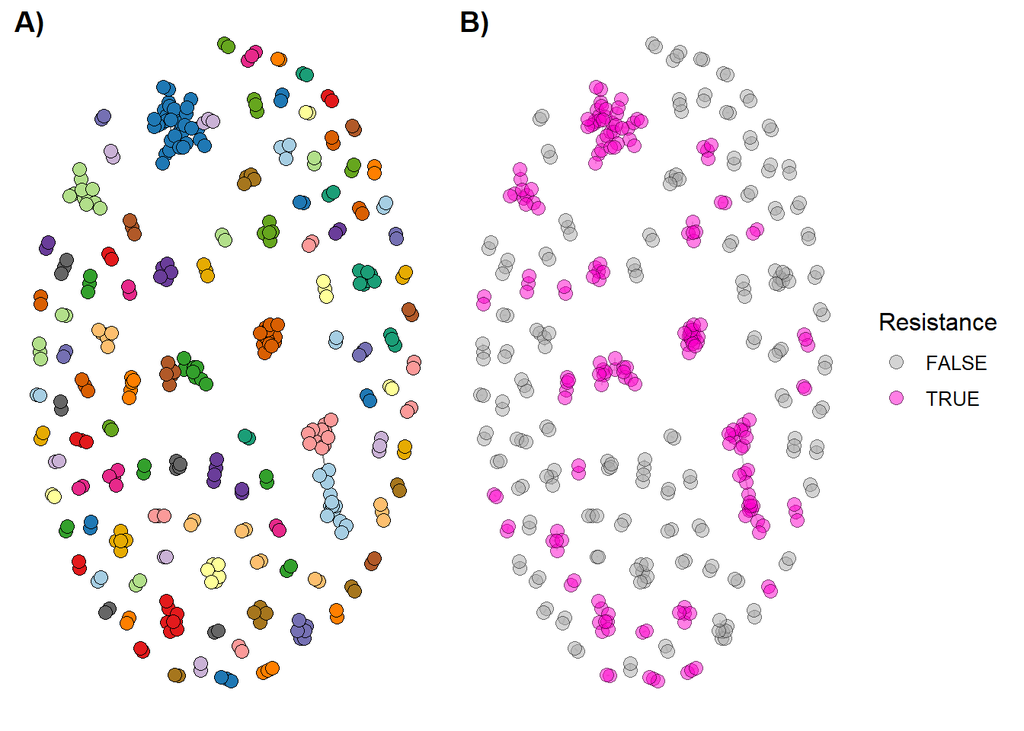

```r
p1<-ggplot(n, aes(x = x, y = y, xend = xend, yend = yend, label = ClusterMembership)) +
  geom_edges( color = "black", alpha = 0.5) +
  theme_blank()+
  geom_nodes(aes( fill = ClusterMembership), pch = 21, size =3)+
  scale_size(range = c(2,6))+
 # ggtitle("Putative plasmid clusters")+
  scale_fill_manual(values = mypal3)+
  theme(legend.position = "none")

  p2<-ggplot(n, aes(x = x, y = y, xend = xend, yend = yend, label = name)) +
  geom_edges( color = "grey", alpha = 0.7) +
  theme_blank()+
  geom_nodes(aes(fill = Resistance), pch = 21, alpha = 0.5, size = 3)+
  scale_size(range = c(1.5,6))+
 # ggtitle("Plasmid-plasmid cluster network coloured by AMR presence")+
  scale_fill_manual(values = c("darkgrey", "#ff00cc"))

ggarrange(p1, p2, labels = c("A)", "B)"), widths = c(1,1.3))
```

```r
#ggsave("C:/Users/risel/Dropbox/Sommer postdoc/Plasmid project/PlasmidProjectAnalysis/Updated analysis2/FIGURES_NC/plasmid_clusters.pdf")

#check k141_736244
```

## 4.5 Calculate plasmid length

```r
## add number of contigs that make up each cluster

contig_no<-data.frame(table(cluster_df$ClusterMembership))
cluster_df$ContigNo<-expss::vlookup(cluster_df$ClusterMembership, contig_no, lookup_column = "Var1", result_column = "Freq")

## add contig length
contig_length <- read.table("C:/Users/risel/Dropbox/Sommer postdoc/Plasmid project/PlasmidProjectAnalysis/Updated analysis2/DATA/contig_length.tsv", quote="\"", comment.char="")


cluster_df$LengthKB<- vlookup(cluster_df$name, contig_length, lookup_column = 1, result_column = 2)


summary(cluster_df$LengthKB)
```

```
##    Min. 1st Qu.  Median    Mean 3rd Qu.    Max.
##     206    1984    3703    5570    6878   47938
```

```r
plasmid_length<-cluster_df %>% group_by(ClusterMembership) %>% summarise(TotalLengthKB = sum(LengthKB))

summary(plasmid_length$TotalLengthKB)
```

```
##    Min. 1st Qu.  Median    Mean 3rd Qu.    Max.
##    1351    4845    8772   19368   21611  240077
```

# 5 Filter and merge

## 5.1 Keep only MAG-PLASMID associations

- Ultimately, we are interested in Mag-plasmid connections
- So at this point, we filter down our HiC links df to include only links between MAG contigs and plasmid contigs
- We couldnt do this before, because we didn’t know which plasmid contigs to keep (based on clustering)

```r
# keep only links that involve MAGs, and make sure they are all in one column
# at the moment they are spread out across the left and right columns

mag1<- subset(WW_links_filt5, contig1_assignment=="MAG")
mag2<- subset(WW_links_filt5, contig2_assignment=="MAG")

# change columns of mag2 around so they match mag1
mag2<-mag2[,c(2,1,3,5,4)]
names(mag2)<-names(mag1)

WW_links_filt6<-rbind(mag1, mag2)

# change column names
names(WW_links_filt6)[1:3]<-c("contigs_mags", "contigs_plasmids", "Count")

table(WW_links_filt6$contig2_assignment) # still AMR genes in there. Remove
```

```
##
##     AMR PLASMID
##    7333  243014
```

```r
WW_links_filt6<-subset(WW_links_filt6, contig2_assignment == "PLASMID")
```

- Only keep plasmid contigs that are clustered
- This information is stored in the object “cluster_df”

```r
WW_links_filt6$Cluster<- vlookup(WW_links_filt6$contigs_plasmids, cluster_df, lookup_column = "name", result_column = "ClusterMembership")

length(unique(WW_links_filt6$Cluster)) # how many clusters?
```

```
## [1] 110
```

```r
WW_links_filt6$Cluster<-factor(WW_links_filt6$Cluster)

# remove any plasmid inks that are not assigned a cluster
WW_links_filt7<-na.omit(WW_links_filt6)
```

## 5.2 Add MAG bin assignment info to link df

```r
WW_links_filt7$MAG_assigment<-vlookup(WW_links_filt7$contigs_mags, mag_assignment, lookup_column = "contigs", result_column = "cluster")
```

## 5.3 Merge by MAG AND plasmid cluster

```r
WW_links_filt8<- WW_links_filt7 %>% group_by(MAG_assigment, Cluster) %>% summarise(Count = sum(Count))
```

## 5.4 Remove singletons

```r
WW_links_filt9<-subset(WW_links_filt8, Count >1) # changed
```

## 5.5 Add resistance metadata

- Plasmid clusters that are associated with AMR are stored in the object “resistance_clusters”

```r
WW_links_filt9$Resistance<-WW_links_filt9$Cluster %in% resistance_clusters

# how many unique plasmid clusters associate with AMR?
table(unique(WW_links_filt9[,c(2,4)])$Resistance)
```

```
##
## FALSE  TRUE
##    77    32
```

# 6 Normalise data

## 6.1 Normalise by MAG abundance

- MAGs vary in their abundance, and this will affect the number of links
- We want the counts normalised in a way that assumes all MAGs were present at the same abundance
- To get this ‘theoretical’ same abundance, I use the mean abundance across MAGs
- If the mean abundance is 1%, but there is a MAG with 2% abundance, I normalise the count by multiplying it by (1/2 = 0.5).
- In this case, 0.5 is called the ‘scaling factor’ that I multiply counts by
- The scaling factor for each MAG is the mean MAG abundance divided by the specific MAG abundance
- However, I always add a psudocount of 1, to make sure when rounded, there are no zero counts (minimum count should always be 1)
- Same as just dividing by MAG abundance, but then you get <0 which is problematic for networks

```r
MAG_metadata <- read.csv(here("DATA","MAG_metadata.csv"))

MAG_metadata<-MAG_metadata[,1:8]

WW_links_filt9$Abundance<-vlookup(WW_links_filt9$MAG_assigment, MAG_metadata, lookup_column = "cluster_id", result_column = "abundance")

# generate scaling factor to normalise by

WW_links_filt9$Scaling_factor<-  mean(WW_links_filt9$Abundance)/WW_links_filt9$Abundance

WW_links_filt9$Count_normalised<-WW_links_filt9$Count*WW_links_filt9$Scaling_factor
WW_links_filt9$Count_normalised<-WW_links_filt9$Count_normalised+1 # add psudocount of one so we can round it to the nearest integer (minimum 1)

WW_links_filt9$Count_normalised<-round(WW_links_filt9$Count_normalised,0)
```

## 6.2 Normalise by plasmid size

```r
WW_links_filt9$PlasmidLength<- vlookup(WW_links_filt9$Cluster, plasmid_length, lookup_column = 1, result_column = 2)


WW_links_filt9$Scaling_factor_length<-  mean(WW_links_filt9$PlasmidLength)/WW_links_filt9$PlasmidLength

WW_links_filt9$Count_normalised1<-WW_links_filt9$Count_normalised*WW_links_filt9$Scaling_factor_length
WW_links_filt9$Count_normalised1<-WW_links_filt9$Count_normalised1+1 # add psudocount of one so we can round it to the nearest integer (minimum 1)

WW_links_filt9$Count_normalised1<-round(WW_links_filt9$Count_normalised1,0)
WW_links_filt9$Count_normalised<-WW_links_filt9$Count_normalised1
```

# 7 Process data for final analysis

## 7.1 Convert count table into adjacency matrix

We have finished filtering, but at this point we need to generate a few bits of final information so that we can put it all together into a phyloseq object. Phyloseq is an R package that is used to handle 16S microbiome data, but it can also be used to handle other sorts of data like bacteria-plasmid associations.

We need: 1) A MAG x Plasmid count table/adjacency matrix 2) A dataframe with metadata for each MAG (eg Taxonomy) 3) a dataframe with metadata for each plasmid (ie Whether it has a resistance gene or not)

```r
# first we make the MAG x plasmic count table

WW_links_clustered2<-WW_links_filt9[,c("MAG_assigment", "Cluster", "Count_normalised")]

count_table_clustered<- pivot_wider( WW_links_clustered2, names_from = MAG_assigment, values_from = Count_normalised)


##turn NAs to zeros
count_table_clustered_dt<-as.data.table(count_table_clustered)
count_table_clustered_dt[is.na(count_table_clustered_dt)] <- 0
count_table_clustered_dt[1:5, 1:5]
```

| Cluster | bin_1 | bin_10 | bin_103 | bin_104 |
| --- | --- | --- | --- | --- |
| 2 | 4 | 8 | 7 | 0 |
| 5 | 17 | 0 | 0 | 418 |
| 30 | 6 | 1059 | 0 | 0 |
| 1 | 0 | 2 | 0 | 241 |
| 3 | 0 | 3 | 49 | 0 |

```r
count_table_clustered_df<-data.frame(count_table_clustered_dt)
#count_table_clustered_df[1:5,1:5]

#make first col row names
row.names(count_table_clustered_df)<-count_table_clustered_df$Cluster

# remove first column
count_table_clustered_df<-count_table_clustered_df[,-1]
count_table_clustered_df[1:5,1:5]
```

|  | bin_1 | bin_10 | bin_103 | bin_104 | bin_105 |
| --- | --- | --- | --- | --- | --- |
| 2 | 4 | 8 | 7 | 0 | 15 |
| 5 | 17 | 0 | 0 | 418 | 0 |
| 30 | 6 | 1059 | 0 | 0 | 52 |
| 1 | 0 | 2 | 0 | 241 | 0 |
| 3 | 0 | 3 | 49 | 0 | 0 |

```r
# plasmid clusters are rows, MAGs are columns


# remove normalised links under 5
count_table_clustered_df[count_table_clustered_df < 5] <- 0
```

## 7.2 Re-add MAGs that don’t associate with any plasmids

- MAGs which don’t associate with any plasmids were filtered out, therefore we need to add these back in

```r
# add column for bacterial species that are not associated with any plasmids
# these got removed as they had zero counts
mag_IDs<-unique(mag_assignment$cluster)
mags_to_add<-data.frame(mag_IDs)
mags_to_add$Included<-mags_to_add$mag_IDs %in% names(count_table_clustered_df)
mags_to_add<-subset(mags_to_add, Included==FALSE)
df_to_add<-data.frame(matrix(0, nrow = nrow(count_table_clustered_df), ncol = nrow(mags_to_add)))
names(df_to_add)<-mags_to_add$mag_IDs
row.names(df_to_add)<-row.names(count_table_clustered_df)
new_count_table_clustered<-cbind(count_table_clustered_df, df_to_add)
```

## 7.3 Generate MAG metadata

```r
phylophlan_taxonomy <- read.csv(here("DATA","phylophlan_taxonomy_updated.csv"))

MAG_metadata<-MAG_metadata[,1:8]

new_mag_metadata<-merge(MAG_metadata, phylophlan_taxonomy, by.x = "cluster_id", by.y = "Bin")
row.names(new_mag_metadata)<-new_mag_metadata$cluster_id
```

## 7.4 Generate plasmid metadata

```r
plasmid_metadata_clustered<-data.frame(unique(WW_links_filt9$Cluster))
names(plasmid_metadata_clustered)<-"contigs_plasmids"

plasmid_metadata_clustered$Resistance<- plasmid_metadata_clustered$contigs_plasmids %in% resistance_clusters

row.names(plasmid_metadata_clustered)<-plasmid_metadata_clustered$contigs_plasmids

# turn it into a tax_table object
plasmid_metadata_clustered<-tax_table(plasmid_metadata_clustered)
taxa_names(plasmid_metadata_clustered)<-data.frame(plasmid_metadata_clustered)$ta1
```

## 7.5 Convert all layers into phyloseq object

```r
OTU = otu_table(new_count_table_clustered, taxa_are_rows = TRUE)
dim(new_count_table_clustered)
```

```
## [1] 109 379
```

```r
plasmid_ps_clustered<-merge_phyloseq(OTU, sample_data(new_mag_metadata), plasmid_metadata_clustered)

plasmid_ps_clustered
```

```
## phyloseq-class experiment-level object
## otu_table()   OTU Table:         [ 109 taxa and 379 samples ]
## sample_data() Sample Data:       [ 379 samples by 15 sample variables ]
## tax_table()   Taxonomy Table:    [ 109 taxa by 2 taxonomic ranks ]
```

```r
## saveRDS(plasmid_ps_clustered, "plasmid_ps_clustered_genomad_final.RDS")
# saveRDS(plasmid_ps_clustered, "C:/Users/risel/Dropbox/Sommer postdoc/Plasmid project/PlasmidProjectAnalysis/Updated analysis2/R_OUTPUT/plasmid_ps_clustered_genomad_final.RDS")
```